# Course Project 1

Andy Domenico

Loading and preprocessing the data

First, import any needed libraries.

```r
echo=TRUE
library(dplyr)
```

```r
library(ggplot2)
library(data.table)
library(readr)
```

We will need to download the data from the course website. This should only need to be done once. The URL and the date/time of download should be embedded in the workbook. The data will be stored in a data directory. If such a directory does not exist, the below code will create it.

```r
echo=TRUE
if(!dir.exists("./data")) {
  dir.create("./data")
} else {
  print("Data directory already exists")
}
```

```
## [1] "Data directory already exists"
```

Now data can be downloaded and stored in the new data directory

```r
echo=TRUE
fileUrl <- "https://d396qusza40orc.cloudfront.net/repdata%2Fdata%2Factivity.zip"
dest <- "./data/activity.zip"
download.file(fileUrl, dest)

#unzip the file
unzip(dest, exdir="./data")

print(paste0('Data retrieved from ', fileUrl, ' at ', Sys.time()))
```

```
## [1] "Data retrieved from https://d396qusza40orc.cloudfront.net/repdata%2Fdata%2Factivity.zip at 2022-04-23 21:11:27"
```

The data from the .csv file can now be read into a data frame. This is raw data and will be explored. We expect to transform the data

```r
echo=TRUE
raw_df <- read.csv("./data/activity.csv")
```

The first question to address is: “What is mean total number of steps taken per day?”

In order to answer that question, we need to examine the quality of the data.  
Does it contain missing values or extreme outliers? performing a simple head() command reveals that there are indeed NA values. For purposes of this analysis removing NA is acceptable.

Testing for outliers is as simple as looking at a summary and drawing a histogram. Let us start with a summary:

```r
echo = TRUE
no_na_df <- na.omit(raw_df)
no_na_df$date <- as.Date(no_na_df$date)
summary(no_na_df$steps)
```

```
##    Min. 1st Qu.  Median    Mean 3rd Qu.    Max.
##    0.00    0.00    0.00   37.38   12.00  806.00
```

It seems that there are a lot of 0 values, especially if the median is 0. Let’s remove all rows that have a 0 value for steps and redo the summary.

```r
echo=TRUE
rm0_df <- no_na_df %>%
  filter(steps != 0)
```

```r
echo=TRUE
summary(rm0_df$steps, rm.na=TRUE)
```

```
##    Min. 1st Qu.  Median    Mean 3rd Qu.    Max.
##     1.0    25.0    56.0   134.3   146.8   806.0
```

We can now draw a histogram using base plotting

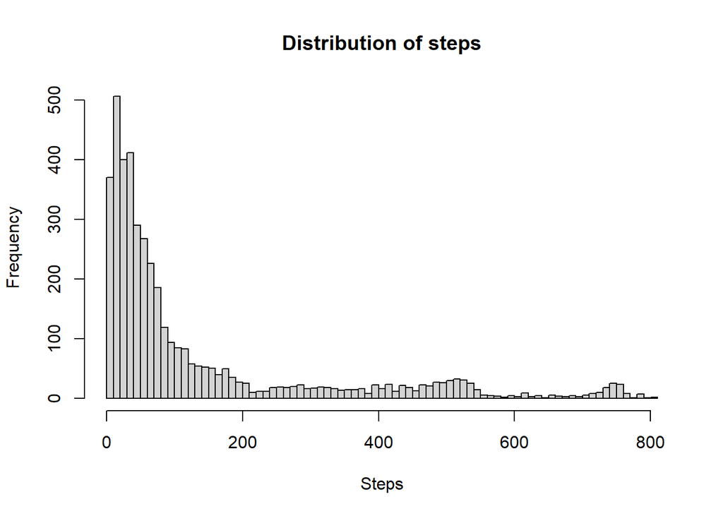

```r
echo=TRUE
hist(rm0_df$steps,
     xlab = "Steps",
     main = "Distribution of steps",
     breaks = sqrt(nrow(rm0_df)),
     rm.na=TRUE
)
```

The histogram seems to show that most 5 minute intervals have a low number of steps and few have a high number up towards 800. Performing 800 steps in a single 5 minute interval is probably a strenuous exercise period, but not out of the range of possibility and there are data points in the 600-800 range so these higher values don’t appear to be high outliers.

To calculate the total number of steps taken per day, we can group by day and redo the histogram

```r
echo=TRUE
daily_df <- rm0_df %>%
  group_by(date) %>%
  summarise(daily_steps = sum(steps))
```

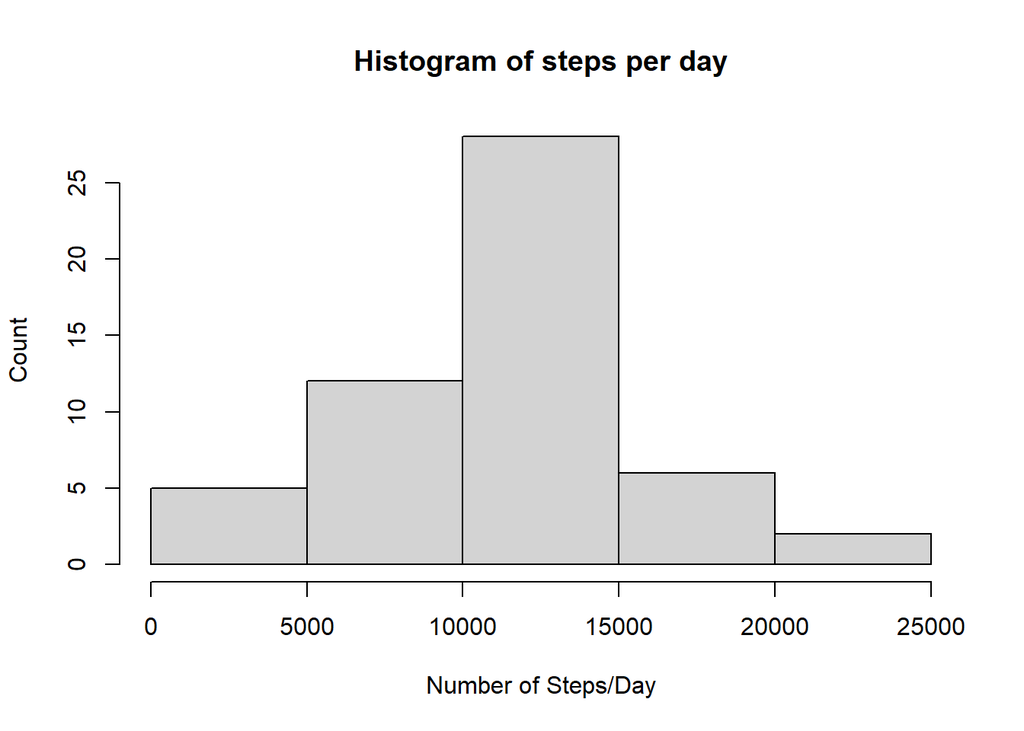

```r
echo=TRUE
hist(daily_df$daily_steps,
     xlab="Number of Steps/Day",
     ylab="Count",
     main="Histogram of steps per day")
```

Given this data, the next task is to calculate and report the mean and median of the total number of steps taken per day

```r
echo=TRUE
mean_steps <- mean(daily_df$daily_steps)
med_steps <- median(daily_df$daily_steps)
print(paste0("The mean number of steps per day is ", mean_steps, " and the median number of steps per day is ", med_steps))
```

```
## [1] "The mean number of steps per day is 10766.1886792453 and the median number of steps per day is 10765"
```

Now that we have a basic idea of the data, we ask “What is the average daily activity pattern?”

To answer this, we will make a time series plot (i.e. type = “l”) of the 5-minute interval (x-axis) and the average number of steps taken, averaged across all days (y-axis). Start by grouping by interval and computing the average for each interval

```r
echo=TRUE
int_avg_df <- no_na_df %>%
  group_by(interval) %>%
  summarize(AvgSteps=mean(steps))
```

Now to create the plot

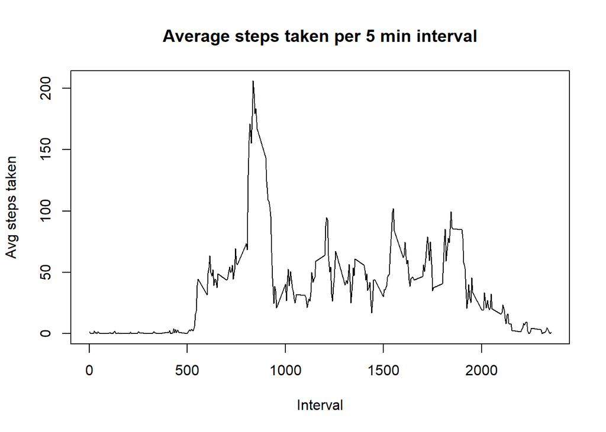

```r
echo=TRUE
plot(int_avg_df$interval, int_avg_df$AvgSteps,
     type = "l",
     xlab="Interval",
     ylab="Avg steps taken",
     main="Average steps taken per 5 min interval")
```

Now we want know which 5-minute interval, on average across all the days in the dataset, contains the maximum number of steps?

```r
echo=TRUE
max_steps <- int_avg_df$interval[which.max(int_avg_df$AvgSteps)]
print(paste0("The interval with the maximum number of steps is ", max_steps))
```

```
## [1] "The interval with the maximum number of steps is 835"
```

**Imputing missing values**

Note that there are a number of days/intervals where there are missing values (coded as NA). The presence of missing days may introduce bias into some calculations or summaries of the data.

We want to calculate and report the total number of missing values in the dataset (i.e. the total number of rows with NAs)

```r
echo=TRUE
num_nas <- colSums(is.na(raw_df))
print(paste0("The number of NAs in the data is ", num_nas))
```

```
## [1] "The number of NAs in the data is 2304"
## [2] "The number of NAs in the data is 0"
## [3] "The number of NAs in the data is 0"
```

Devise a strategy for filling in all of the missing values in the dataset. The strategy does not need to be sophisticated. For example, you could use the mean/median for that day, or the mean for that 5-minute interval, etc.

The strategy we will use here is to iterate over all the rows and find the index value where the interval matches the average (computed above when we got the mean for each five minute interval), then take that value and replace the NAs with that value. We see from the above step that NA only exists in the’steps’ column, so that’s the only one we need to be concerned with.

Create a new dataset that is equal to the original dataset but with the missing data filled in.

```r
echo=TRUE
filled_df <- raw_df
for (i in 1:nrow(filled_df)) {
  if(is.na(filled_df$steps[i])) {
    index_avg <- which(filled_df$interval[i] == int_avg_df$interval)
    filled_df$steps[i] <- int_avg_df[index_avg,]$AvgSteps
  }
}
```

Let’s make a histogram of the total number of steps taken each day

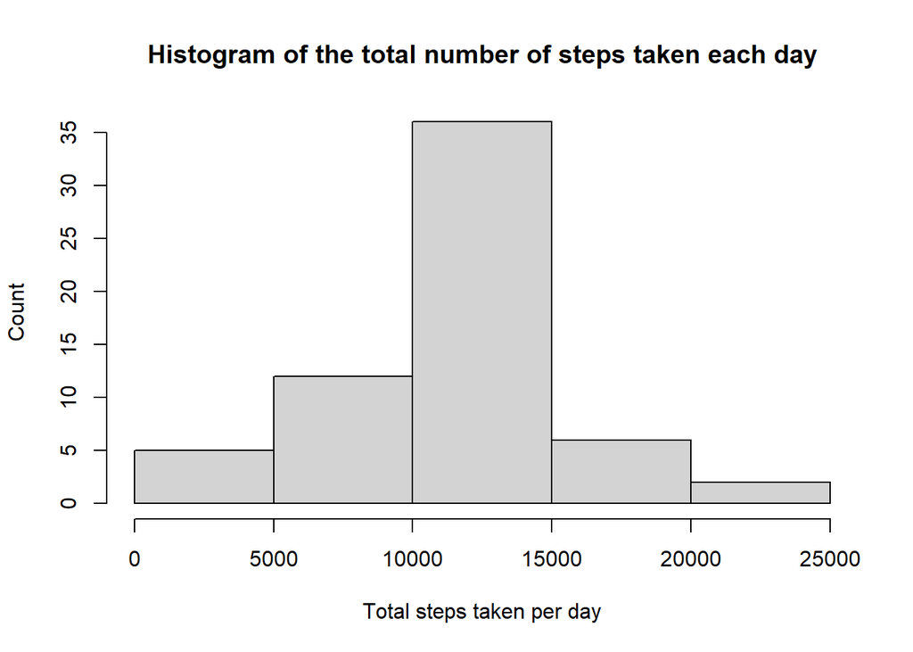

```r
echo=TRUE
filled_by_day <- filled_df %>%
  group_by(date) %>%
  summarize(TotalSteps=sum(steps))

hist(filled_by_day$TotalSteps,
     xlab="Total steps taken per day",
     ylab="Count",
     main="Histogram of the total number of steps taken each day")
```

Now we want to calculate and report the mean and median total number of steps taken per day

```r
echo=TRUE
filled_mean_steps <- mean(filled_by_day$TotalSteps)
filled_med_steps <- mean(filled_by_day$TotalSteps)
print(paste0("The mean number of steps when values are imputed is ", filled_mean_steps, " and the median number of steps when values are imputed is ", filled_med_steps))
```

```
## [1] "The mean number of steps when values are imputed is 10766.1886792453 and the median number of steps when values are imputed is 10766.1886792453"
```

**Are there differences in activity patterns between weekdays and weekends?** For this part the weekdays() function may be of some help here. Use the dataset with the filled-in missing values for this part.

We will create a new factor variable in the dataset with two levels – “weekday” and “weekend” indicating whether a given date is a weekday or weekend day.

```r
echo=TRUE
filled_df$date <- as.Date(filled_df$date)
filled_df$day <- weekdays(filled_df$date)
#label Sat & Sun as weekend & all other days as weekday
filled_df$daytype <- "weekday"
filled_df$daytype[filled_df$day %in% c("Saturday", "Sunday")] <- "weekend"
```

Make a panel plot containing a time series plot (i.e. type = “l”) of the 5-minute interval (x-axis) and the average number of steps taken, averaged across all weekday days or weekend days (y-axis). See the README file in the GitHub repository to see an example of what this plot should look like using simulated data.

```r
echo=TRUE
dayaverage <- filled_df %>%
  group_by(daytype, interval) %>%
  summarize(AvgSteps = mean(steps))
```

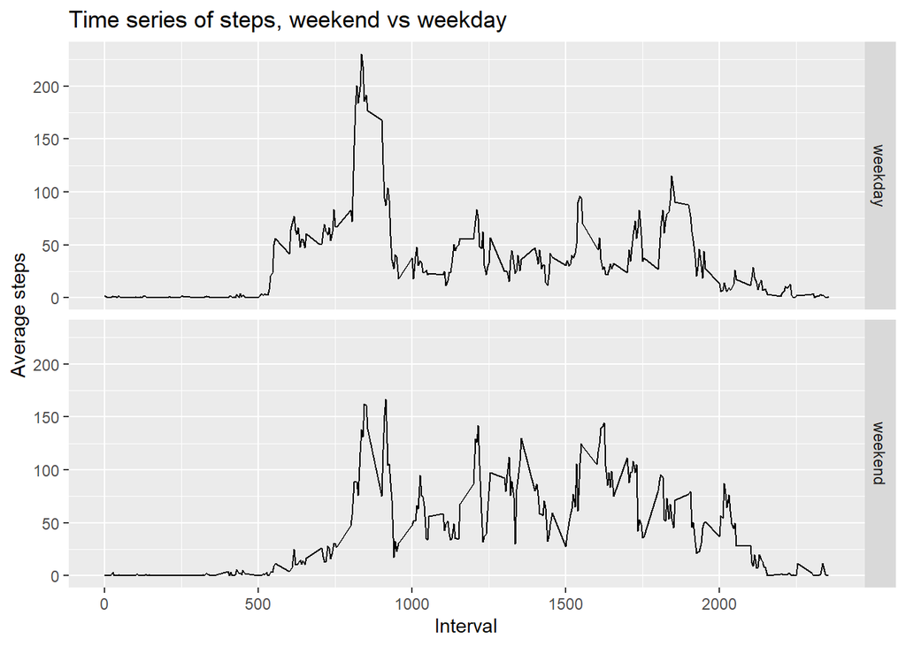

```r
qplot(interval, AvgSteps, data=dayaverage,
      type="l",
      geom="line",
      xlab="Interval",
      ylab="Average steps",
      main="Time series of steps, weekend vs weekday",
      facets = daytype ~.)
```